# Leptospirosis in Kazakhstan: Exercise in R

### 4.2.2 Univariable summaries of categorical variables

- Create summaries of the categorical variables for symptom variables: diarrhea, fever, illness, outcome, pain, vomit
- Using Rcmdr menu:

Statistics -> Summaries -> Frequency distributions

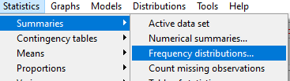

- Select variables for frequency distribution.

[figure not shown]

- Categorical data analysis using RStudio.

```r
> ## count categories headache
> table(leptodbfinal$headache)
```

```
 1  2  3  4
17  9  1  2
```

```r
> ## count proportions of headache
> round(prop.table(table(leptodbfinal$headache)),2)
```

```
   1    2    3    4
0.59 0.31 0.03 0.07
```

- Repeat same for all variables you need to analize.

## 4.3 Bivariable analysis - t-test

- Create summaries of the numerical variables by category, for example, age by case_status
- Using Rcmdr menu:

Statistics -> Means -> Independent samples t-test

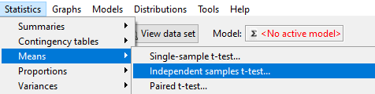

- In the dialogue window that opens up, select the groups variable: status
- Select in the response variable: age

[figure not shown]

- Calculate age difference usig ttest

```r
> t.test(age ~ status, data = leptodbfinal)
```

```
    Welch Two Sample t-test

data:  age by status
t = -0.25411, df = 40.786, p-value = 0.8007
alternative hypothesis: true difference in means between group Case and group Control is not equal to 0
95 percent confidence interval:
 -9.282865  7.208200
sample estimates:
   mean in group Case mean in group Control
             31.89655              32.93388
```

## 4.4 Bivariable analysis - chi-square

- Create summaries of the categorical variables by category, for example, age_group by status
- Using Rcmdr point-and-click:

Statistics -> Proportions -> Two-sample proportions test

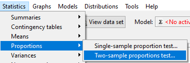

- In the dialogue window that opens up, select the groups variable: age_group
- Select in the response variable: status

[figure not shown]

- Use RStudio to calculate data.

```r
> chiqtbl <- xtabs(~ age_group + status, data = leptodbfinal)
> chiqtbl
```

```
         status
age_group Case Control
    <15      5      18
    10-39   16      62
    40+      8      41
```

```r
> chisq.test(chiqtbl)
```

```
    Pearson's Chi-squared test

data:  chiqtbl
X-squared = 0.43899, df = 2, p-value = 0.8029
```

## 4.5 Bivariable analysis - odds ratio

- Recode variable **status** into **statusn** and make **Case = 1** and **Control = 0**, this is necesary to fit models and calcualate **Odds Ratio**.
- Conduct this in R Commander.

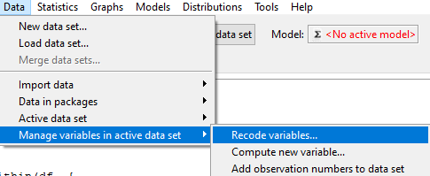

- In the recode window we need to enter code to recode cases and controls

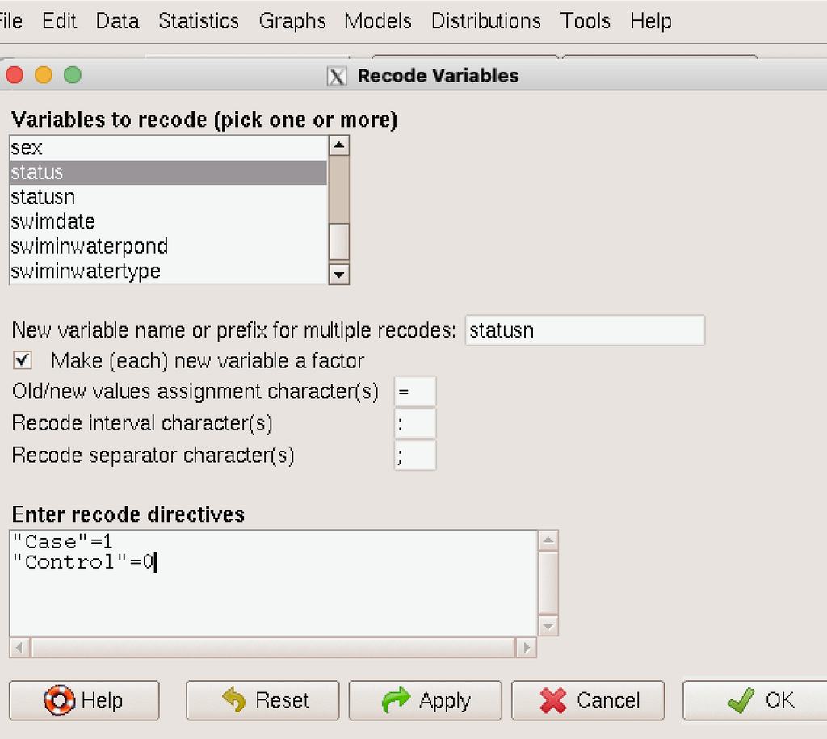

- Recoding in RStudio.

```r
> leptodbfinal$statusn <- ifelse(leptodbfinal$status == "Case", 1, 0)
```

- Using Rcmdr menu:

Statistics -> Fit models -> Generalized linear models

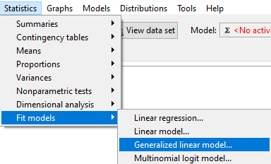

[figure not shown]

- Resutls

[figure not shown]

- Next get confidence intervals for our outputs

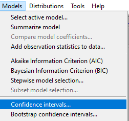

- In the window you should select

[figure not shown]

- You get results:

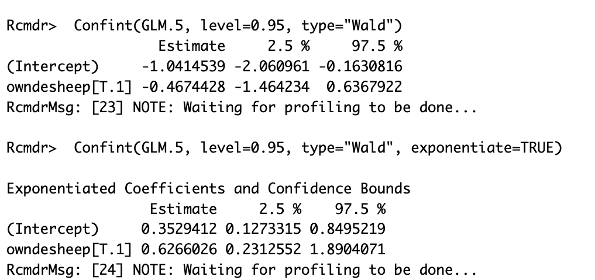

```r
> ## Calculate OR using, create model
> GLMOR <- glm(statusn ~ owndesheep, family=binomial(logit), data=leptodbfinal)
> ## Calculate summary of OR
> summary(GLMOR)
```

```
Call:
glm(formula = statusn ~ owndesheep, family = binomial(logit),
    data = leptodbfinal)

Coefficients:
            Estimate Std. Error z value Pr(>|z|)
(Intercept)  -1.7346     0.6262  -2.770  0.00561 **
owndesheep1   0.2257     0.6673   0.338  0.73517
---
Signif. codes:  0 '***' 0.001 '**' 0.01 '*' 0.05 '.' 0.1 ' ' 1

(Dispersion parameter for binomial family taken to be 1)

    Null deviance: 137.18  on 146  degrees of freedom
Residual deviance: 137.07  on 145  degrees of freedom
  (3 observations deleted due to missingness)
AIC: 141.07

Number of Fisher Scoring iterations: 4
```

```r
> ## Exponentiated coefficients
> exp(coef(GLMOR))
```

```
(Intercept) owndesheep1
  0.1764706   1.2532051
```

```r
> ## Calcualte confidence intervals
> Confint(GLMOR, level=0.95, type="LR", exponentiate=TRUE)
```

```
Exponentiated Coefficients and Confidence Bounds
```

```
             Estimate      2.5 %    97.5 %
(Intercept) 0.1764706 0.04119821 0.5251961
owndesheep1 1.2532051 0.38038585 5.6806361
```

# 5 Descriptive analysis and distribution of symptoms of Leptospirosis in the outbreak data.

- Codes for R to create complex nice looking tables using **GTsummary** package.

```r
> #table for gender by age years
> leptb1 <- leptocase %>%
+   select(c(sex, age)) %>%
+  tbl_summary(by = sex,
+               percent = "column",
+               sort = all_categorical() ~ "frequency",
+               statistic = list(
+                 all_continuous() ~ "{mean} ({sd})",
+                 all_categorical() ~ "{n} ({p})"
+               ),
+
+               missing_text = "Unk.")%>%
+   modify_header(label = "**Gender and age(years)**") %>%
+   bold_labels()
> # add_p(test = list(all_categorical() ~ "chisq.test")) %>%
> # bold_p(t = .05)
> leptb1 <- as_flex_table(leptb1)
>
> #table for sex and by age_groupoups
> leptb2 <- leptocase %>%
+   select(c(sex, age_group)) %>%
+  tbl_summary(by = sex,
+               percent = "column",
+               #sort = all_categorical() ~ "frequency",
+               statistic = list(
+                 all_continuous() ~ "{mean} ({sd})",
+                 all_categorical() ~ "{n} ({p})"
+               ),
+
+               missing_text = "Unk.")%>%
+   modify_header(label = "**Gender and age(years)**") %>%
+   bold_labels()
> leptb2 <- as_flex_table(leptb2)
>
>
> leptb3 <- leptocase %>%
+   select(c(headache, fever, chils, myalgia)) %>%
+   mutate(headache = fct_recode(headache, "SEVERE" = "1", "INTERMED" = "2", "MILD" = "3", "NO PAIN" = "4", "NA" = "0"), fevern = as.numeric(fever)) %>%
+  tbl_summary(#by = admy,
+               percent = "column",
+               sort = all_categorical() ~ "frequency",
+               statistic = list(
+                 all_continuous() ~ "{mean} ({sd})",
+                 all_categorical() ~ "{n} ({p})"
+               ),
+               missing_text = "Unk.") %>%
+   modify_header(label = "**Symptoms of Leptospirosis**") %>%
+   bold_labels()
> leptb3 <- as_flex_table(leptb3)
```

**Task 2.2** Demographic characteristics of cases by gender and age. Are there more males or females affected? Create frequency distribution of N of cases by gender and detect mean values and standard deviation of age? Calculate mean age and standard deviation by gender?.

**Answer 2.2** Frequency distribution of cases by gender and age are provided in the Table 2.

**Table 2.** Cases of Leptospirosis by age and by gender.

| Gender and age(years) | F N = 121 | M N = 171 |
| --- | --- | --- |
| age | 34 (20) | 30 (20) |

1Mean (SD)

**Table 3.** Cases of Leptospirosis by age groups and by gender.

| Gender and age(years) | F N = 121 | M N = 171 |
| --- | --- | --- |
| age_group |  |  |
| <15 | 2 (17) | 3 (18) |
| 10-39 | 6 (50) | 10 (59) |
| 40+ | 4 (33) | 4 (24) |

1n (%)

**Task 2.3** Create a table that summarizes the clinical features of the 29 cases. What does the distribution suggest to you?

**Table 4.** Distribution of leptospurosis symptoms among case patients. Clinical Features of case Patients with Leptospirosis, Kenkolat, East Kazakhstan, August 2004.

| Symptoms of Leptospirosis | N = 291 |
| --- | --- |
| headache |  |
| SEVERE | 17 (59) |
| INTERMED | 9 (31) |
| NO PAIN | 2 (6.9) |
| MILD | 1 (3.4) |
| fever |  |
| 38 | 7 (24) |
| 39 | 4 (14) |
| 38.7 | 2 (6.9) |
| 39.2 | 2 (6.9) |
| 39.5 | 2 (6.9) |
| 37.3 | 1 (3.4) |
| 37.4 | 1 (3.4) |
| 37.5 | 1 (3.4) |
| 37.7 | 1 (3.4) |
| 38.1 | 1 (3.4) |
| 38.5 | 1 (3.4) |
| 38.6 | 1 (3.4) |
| 38.8 | 1 (3.4) |
| 39.3 | 1 (3.4) |
| 39.7 | 1 (3.4) |
| 40 | 1 (3.4) |
| 40.2 | 1 (3.4) |
| chils |  |
| 1 | 29 (100) |
| myalgia |  |
| 1 | 22 (76) |
| 0 | 7 (24) |
| fevern | 8.7 (4.4) |

1n (%); Mean (SD)

**Task 3.1** Create distribution of cases by date of onset of symptoms. Create Epi courve in R using histogram?

**Instructor’s Note:** Interval on X-axis should maximize the clarity of the pattern while preserving important detail. One general guideline is to use ¼ of the average incubation period for the interval. The average incubation period of leptospirosis is 10 days. One fourth of 10 days is 2.5. So, ask the class to use 2 graphs: one with 1-day intervals (for detail), and the other with 3-day intervals (for a general pattern).

**Answer 3.1** Leptospirosis by date of onset of symptoms, Kenkolat, Kazakhstan, July-August 2004.

**Table 5.** Epi curve of cases of Leptospirosis by date of onset of symptoms during outbreak of Kenkolat, Kazakhstan, July-August 2004. (Interval 1 day).

# 6 Create plots/Histogram **Epicurve** in R commaneder and R using **ggplot** packages

- Create histogram using R commander

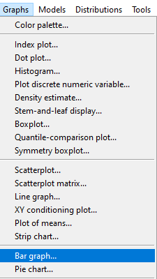

- Select **dateofsymptoms** variable to create histogram

[figure not shown]

- Create histogram in R Commander.

[figure not shown]

- Create histogram using R code.

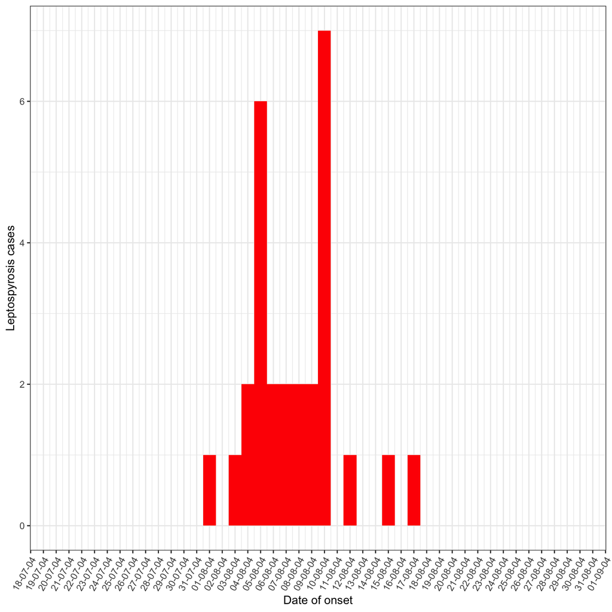

```r
> plot2 <- leptocase %>%
+ ggplot(aes(x = as.Date(dateofsymptoms))) +
+   theme_bw() +
+   stat_bin(binwidth=1, fill = "red") +
+   labs(x="Date of onset", y="Leptospyrosis cases") +
+   theme(axis.text.x=element_text(angle=60, hjust=1)) +
+   scale_x_date(date_breaks = "days", date_labels = "%d-%m-%y",
+   limits=c(ymd("2004-07-20"), ymd("2004-08-30")))
> plot2
```

**Table 6.** Epi curve of cases of Leptospirosis by date of onset of symptoms during outbreak of Kenkolat, Kazakhstan, July-August 2004. (Interval 3 day).

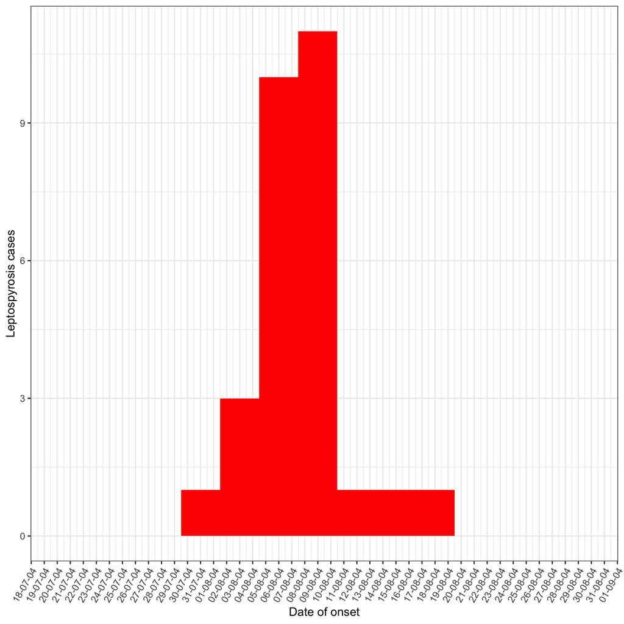

```r
> plot3 <- leptocase %>%
+ ggplot(aes(x = as.Date(dateofsymptoms))) +
+   theme_bw() +
+   stat_bin(binwidth=3, fill = "red") +
+   labs(x="Date of onset", y="Leptospyrosis cases") +
+   theme(axis.text.x=element_text(angle=60, hjust=1)) +
+   scale_x_date(date_breaks = "days", date_labels = "%d-%m-%y",
+   limits=c(ymd("2004-07-20"), ymd("2004-08-30")))
> plot3
```

**Track 4.1** Calculate risk ratios to identify possible factors for the outbreak of Leptospirosis.

**Answer 4.1** Risk Ratios should be calculated for variabels considered as possible risk factors.

**Results of twobytwo table for variable regarding the use of river water**

- You can use same calcualtions to calculate other risk factors or add variables direcltly into the multivariate model.

```r
> leptodbfinal <- leptodbfinal %>%  mutate(casenew = ifelse(status == "Case", 1 , 0),
+                                rivwtr = ifelse(homeusedwaterriver == "YES", 1 , 0))
>
> ## Calculate RR using tbl_uvregression
>
> leptodbfinal %>%
+   select(casenew, rivwtr, ratinyard) %>%
+   tbl_uvregression(
+     method = glm,
+     y = casenew,
+     method.args = list(family=binomial(logit)),
+     exponentiate = TRUE,
+     hide_n = TRUE,
+   #  pvalue_fun = ~ style_pvalue(.x, digits = 2)
+   ) %>%
+   add_global_p() %>% # add global p-value
+   add_nevent() %>% # add number of events of the outcome
+  # add_q() %>% # adjusts global p-values for multiple testing
+   bold_p() %>% # bold p-values under a given threshold (default 0.05)
+   bold_p(t = 0.05) %>% # now bold q-values under the threshold of 0.10
+   bold_labels()
```

| **Characteristic** | **Event N** | **OR**<sup>1</sup> | **95% CI**<sup>1</sup> | **p-value** |
| --- | --- | --- | --- | --- |
| rivwtr | 26 | 3.74 | 1.48, 10.8 | 0.005 |
| ratinyard | 26 |  |  | 0.001 |
| 0 |  | — | — |  |
| 1 |  | 4.23 | 1.75, 11.1 |  |

<sup>1</sup> OR = Odds Ratio, CI = Confidence Interval

```r
> ## Calculate RR using tbl_uvregression
>
> leptodbfinal %>%
+   select(casenew, rivwtr, ratinyard, ownedgoat, ownedhoarse, ownedcat) %>%
+   tbl_uvregression(
+     method = glm,
+     y = casenew,
+     method.args = list(family=poisson(log)),
+     exponentiate = TRUE,
+     hide_n = TRUE,
+     pvalue_fun = ~ style_pvalue(.x, digits = 2)
+   ) %>%
+   add_global_p() %>% # add global p-value
+  # add_nevent() %>% # add number of events of the outcom
+  # add_q() %>% # adjusts global p-values for multiple testing
+   bold_p() %>% # bold p-values under a given threshold (default 0.05)
+   bold_p(t = 0.05) %>% # now bold q-values under the threshold of 0.10
+   bold_labels()
```

| **Characteristic** | **IRR**<sup>1</sup> | **95% CI**<sup>1</sup> | **p-value** |
| --- | --- | --- | --- |
| rivwtr | 3.03 | 1.29, 8.29 | 0.010 |
| ratinyard |  |  | 0.003 |
| 0 | — | — |  |
| 1 | 3.26 | 1.47, 7.95 |  |
| ownedgoat |  |  | 0.90 |
| 0 | — | — |  |
| 1 | 1.07 | 0.41, 3.67 |  |
| ownedhoarse |  |  | 0.10 |
| 0 | — | — |  |
| 1 | 0.44 | 0.19, 1.19 |  |
| ownedcat |  |  | 0.15 |
| 0 | — | — |  |
| 1 | 1.88 | 0.80, 5.14 |  |

<sup>1</sup> IRR = Incidence Rate Ratio, CI = Confidence Interval

**Instructor’s Note:** Additional judgement and information for instructors to take into account for training.

**Question 5b.** Is the epidemic curve consistent with a point source epidemic?

**Answer 5b.** Yes, this outbreak is consistent with a point source. Since the bulk of leptospirosis cases should have onset from 5 to 14 days after exposure, the bulk of the cases in a point source should occur over 9 days. In this outbreak 10 days pass from the first case onset to August 10 after which cases drop to a very low level. The additional 3 cases from August 12 to 17 could simply represent the tendency of leptospirosis to have a small proportion of cases with incubation periods of up to 4 weeks. Alternatively, these outlying cases could represent some additional or prolonged exposure secondary to the main event.

**Question 5c.** Assume that this is a point source. Using the known facts about leptospirosis, what type of exposure would you expect to explain the point source pattern.

**Answer 5c.** Assuming a point source one can simply determine the midpoint of the epidemic (median) and subtract the median incubation period (9-10 days) to find the most probably date of exposure. The median is August 6-7 (14th case occurs on August 6 and the 15th on August 7). Thus, a good estimate of the date of exposure is July 27-28. One may also subtract the minimum incubation (5 days) from the first case (August 1) yielding July 27. This strengthens the July-27-28 estimate. Counting back only two days (the minimum) from the first case or 28 days (the maximum) from the last case is not reliable because these very short and very long incubations are rare and have a low probability of appearing among the relatively small numbers of cases (29) in this outbreak.

The exposure would need to be brief and intense. Possibilities include transient contamination of water used for drinking, swimming, playing, bathing, or household purposes. Other possibilities could include brief exposure of many people around the same time to an ongoing source, for example gathering temporary workers to harvest rice or holding an outdoor swimming competition in a contaminated lake. Transmission directly from infected mammals or from ongoing rodent infestations would be very unlikely to appear as a point source.

# 7 Hypothesis generating interviews.

The epidemiologists questioned villagers about activities or events that occurred during the last week of July. The villagers reported that several continuous days of rain had caused excessive runoff to come down the normally dry gully, alongside the cattle corral complex, and into the permanent stream. The flow in the permanent stream also increased from the watershed upstream from the village. This stream was normally too small and too shallow for swimming or bathing. It was used to water livestock and gather non-potable water for household use. However, the flood had filled normally shallow pools in the streambed. The villagers had availed themselves of this welcome opportunity for swimming and other water related recreation in the heat of the summer.

Wrap-up **Question 6.** Summarize your findings.

**Answer 6. Clinical:** All cases had an illness with characteristics of leptospirosis. Frequent findings were moderate to high fever, chills, severe headache, and myalgias. MAT results confirmed leptospirosis in 85% of suspected cases.

**Person:** All age groups except the elderly (70 to 99 years old) were affected. Data were too sparse to make strong inferences about other details in the age and sex distribution. However, an excess risk was seen in males from 10 to 29 years old and in both sexes from 60 to 69 years old. The excess risk in 10 to 29 year old males accounted for all of the differences in case count and attack rates between males and females.

**Place:** Cases clustered in the downstream segment of the stream that ran along the northern edge of the village. This area of case clustering was across the river from a dry gully running down a hillside past a cattle corral complex. A spring from which villagers collected drinking water was also close to this gully the cattle corral complex.

**Question 7.** The investigation team decided to perform a case control study to gather more specific data about the possible causes of this outbreak. Based on the descriptive epidemiology, develop a hypothesis that can be tested in a case control study. Explain your reasoning.

Accordingly, the hypothesis would be: “A point source outbreak of leptospirosis among residents of Kenkolat from August 1 to 17 resulted from exposure to water for drinking, general household use, watering livestock or swimming all after an unusual period of continuous rainfall during the last week of July. Water sources suspected of being contaminated were a spring used for drinking water and a permanent stream.”

At the end of the case study the participants may be prompted to open a Calibrated Peer Review assignment to develop the questionnaire to test this hypothesis for the case control study.

**Question 8:** How did this investigation address the basics of [One Health](https://www.cdc.gov/onehealth/basics/index.html)? What additional technical inputs could have strengthened the One Health approach?

**Answer 8:** This investigation involved One Health insomuch that leptospirosis in an important zoonotic disease. The outbreak occurred among a high-risk group for leptospirosis, residents of a rural village where the primary livelihood was raising livestock. A key environmental factor was heavy runoff or flooding from unusual, continuous rain. However, this investigation was limited to epidemiologists. A full One Health investigation could have also used input from microbiologists, veterinarians, environmentalists, and hydrologists. Microbiologist inputs - Isolate, identify, and serotype leptospires from livestock and rodents in the cattle corral complex - Test water from the spring, the well, and the pools in the permanent stream for microbial indicators of water quality - Isolate and serotype pathogenic leptospires from rodents, livestock, and suspected water sources Veterinarian inputs: - Assess the size and composition of the livestock population - Assess the livestock population for evidence of leptospirosis disease and infection - Assess livestock husbandry practices. - Recommend practices to reduce transmission of leptospirosis to and among the livestock Environmentalist inputs - Assess the rodent population with a focus on pest species (rats and mice) - Identify practices that increase rodent harborage and access to food. - Recommend and initiate measures to control pest rodents Hydrologist inputs: - Evaluate rainfall patterns and flood events from records at the nearest weather station. - Demonstrate a pathway for surface water to contaminate the spring. - Recommend solutions to provide sufficient potable water for the village. - Recommend solutions to provide water to livestock to minimize contamination of the stream. - Develop a system to divert runoff from the livestock corrals (commercial and household) away from the permanent stream.

**Question 9:** Before the case control study is started what control measures could be taken.

**Answer 9:** Although waterborne transmission of leptospirosis is only a hypothesis, several problems with the water supply for the village were obvious. These could also cause other waterborne diseases besides leptospirosis. Interim measures could include:

- Recommend that all villagers boil their drinking water until a safe potable water supply is developed.
- Advise the villagers to use rubber boots when engaged in activities at the permanent stream. These activities include but are not limited to collecting household water, watering livestock, washing clothes, wading, swimming, and fishing.
- Discourage villagers from swimming or bathing in the permanent stream.
- Provide livestock with a watering place separate from the stream, preferably downstream from the village.
- Reroute any water runoff channels from the animal corral complex to a point downstream from the village

Investigators and Supervisors from Central Asia Field Epidemiology Training Program:

- G. Aumoldaeva
- A. Turcunbaeva
- S. M. Ajeilat
- M. O. Favorov
- D. Nabirova